# Neural Progenitor Cells for Treatment of Spinal Cord Injury

## Executive summary

- Transplanted GFP+NPCs suppress the level of pro-inflammation in the spinal cord 2 weeks post SCI *more* than saline control. There is no difference in terms of effect on pro-inflammation at 5 and 12 weeks when comparing GFP+NPCs and saline control.
- The suppression in pro-inflammation observed 2 weeks post SCI and caused by NPCs was mainly driven by a suppression of IL-1a (p=0.013), IL-1b (0.0064), IL-2 (p=0.027), IL-12(p70) (p=0.082), TNF-a (p=0.016), GRO/KC (p=0.0049), MCP-1 (p=0.036), MIP-1a (p=0.0077) and IL-7 (p=0.05).

## Data modifications

- **Log2 fold change:** Fold change in relation to healthy control was calculated for each each animal and target separately. Example for target X: I) mean expression for target X in healthy animals was calculated. II) The expression in animal Y for target X was divided by the mean expression of target X in healthy control (fold change). III) log2() was taken of the fold change.

## Statistical analysis

### Evaluation of assumptions

- **Assumption of normality** was evaluated for each target, treatment and time point separately. Example for target X at time point Y in time point Z: this is equivalent to one expression value per biological replicate. These values (n=4 or 5) was used in Shapiro Wilk’s test for normality. Null hypothesis that data is normally distributed was rejected at the 5 % level.
- **Assumption of homogenity of variances** was evaluated for each target and time point separately. Example for target X at time point Y: this is equivalent to one expression value per animal for a total of two treatment groups, i.e. n=8 or 10 observations. The homogenity was assessed between the treatments within time point Y. Null hypothesis that the variances were equal was rejected at the 5 % level.

### Independent intraday two group comparison

- Given that data in both treatment groups within one time point for a target was normally distributed and the variances were *equal* **two-sided non-paired Student’s t test** was used for group comparison. Given that both data was normally distributed in both treatment groups within one time point for a target but the variances were *not equal* **two-sided non-paired Student’s t test** with Welch modification to the degrees of freedom was used.
- Given that data in at least one of the treatment groups within one time point was not normally distributed a **two-sided non-paired Wilcoxon Rank Sum test** was used to evaluate the difference.

### Graphical presentation

- Mean in errorbars are mean of rat (biological replicates). Confidence intervals are 95 % and are based on the biological replicates only.

### Agglomerative hierarchical clustering

- Average expression for each target, time point and treatment were clustered using agglomerative hierarchical clustering and presented with heatmap.

### Independent multiple group within treatment comparison over time

- **One-way ANOVA** was used in case the data was normally distributed at all time points for a target and treatment and the variances where homogenous between the treatments. In case the data was normally distributed but the variances were not homogenous the difference was assessed using **Welch ANOVA**. One-way ANOVA was assumed to be robust against violations of the normality assumption.

### Open source access

R-script and html-report can be accessed at [github](https://github.com/S-B-lab/SCI_NPC_multiplex). Please feel free to fork or make a pull request.

## Pro-inflammation over time

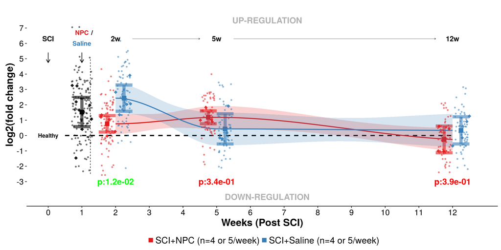

### Distribution of mean based boostrapped data at each time point

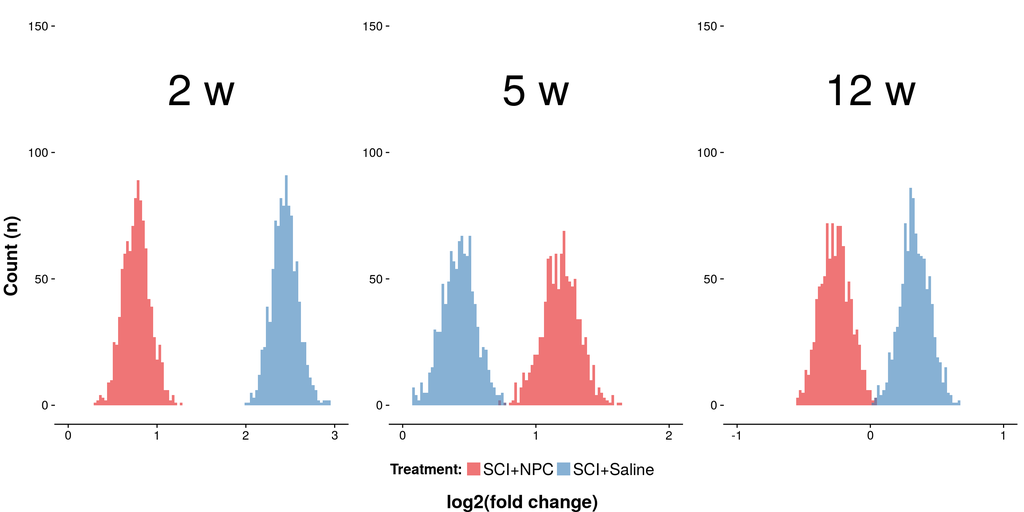

**Figure 2.** Figure reports histograms (100 bins) of 1000 mean log2(fold change) for each treatment and time point. One repeat in the analysis was created by I) bootstrapping data for each animal and time point (pro-inflammatory targets only), II) calculation of mean log2(fold change) per rat and time point, III) calculating the mean log2(fold change) per treatment and time point.

| Treatment | 2w | 5w | 12w |
| --- | --- | --- | --- |
| NPC | 0.770 | 1.189 | -0.264 |
| saline | 2.438 | 0.426 | 0.329 |

### **2 weeks post SCI**

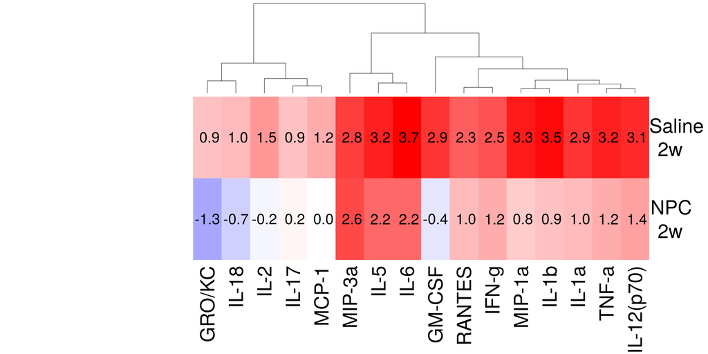

### **5 weeks post SCI**

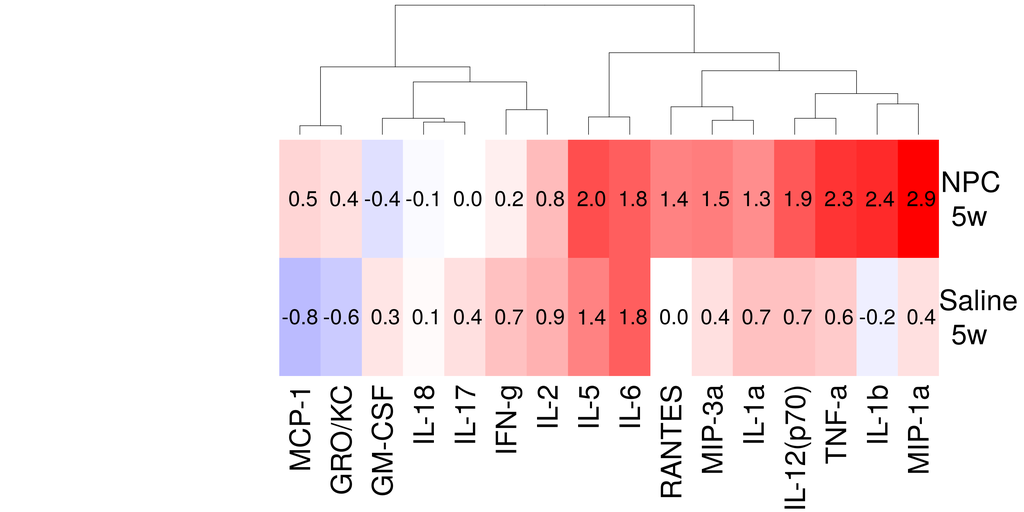

### **12 weeks post SCI**

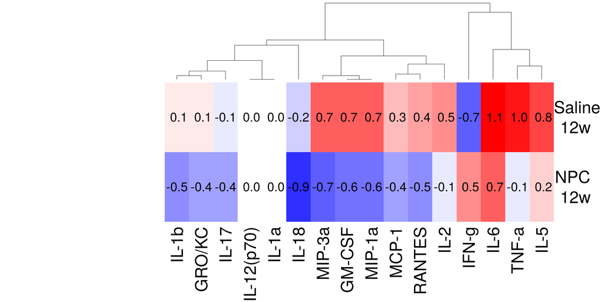

### **2, 5 and 12 weeks**

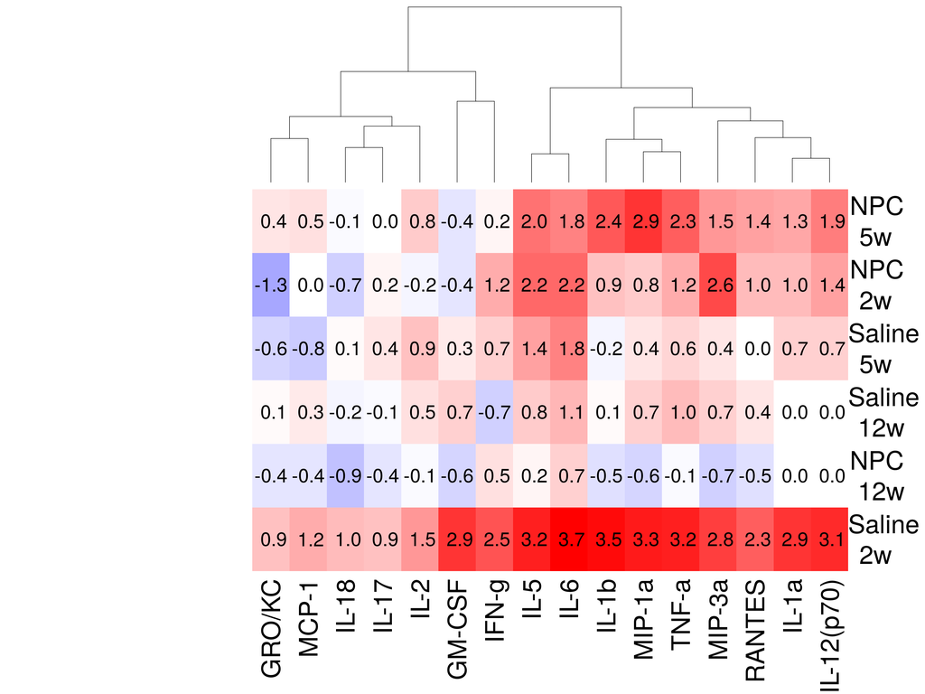

**Figure 3:** Figure reports agglomerative hierarchical clustering with heatmap of pro-inflammatory cytokines/chemokines for each treatment and time point. Values are log2(fold change in expression in relation to mean expresion in healthy control).

## Individual cytokines over time

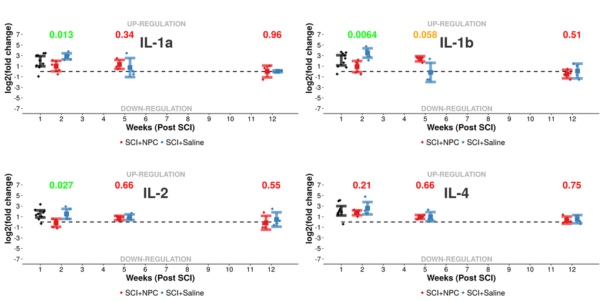

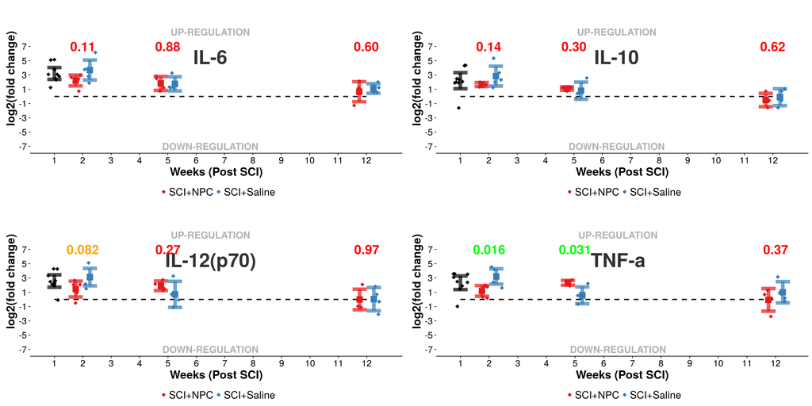

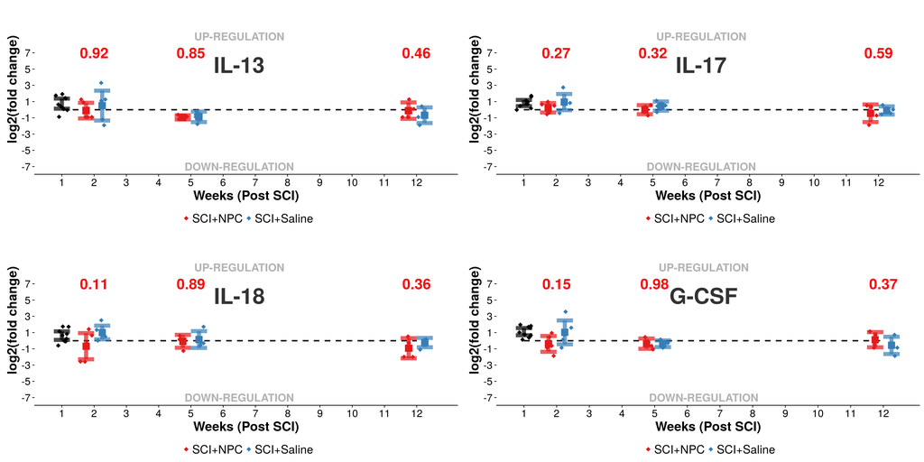

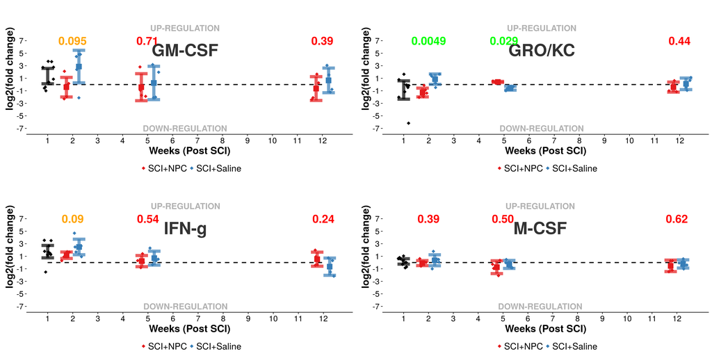

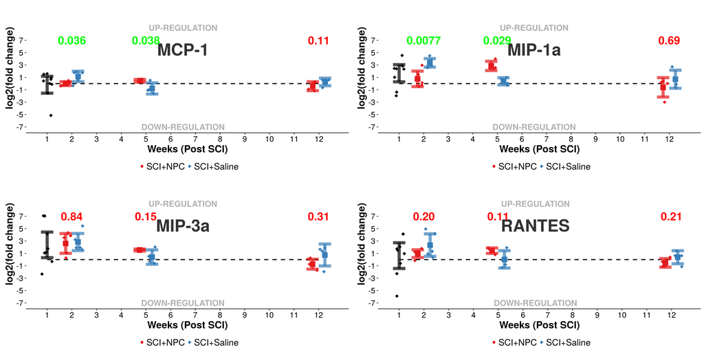

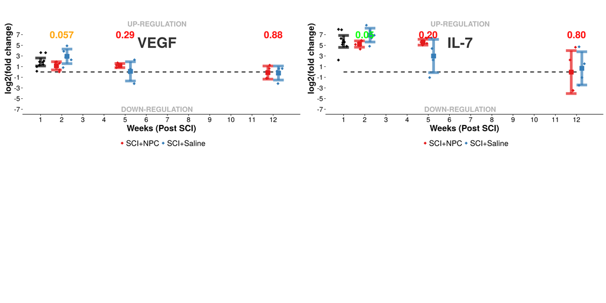

| Week | P-value |
| --- | --- |
| 2 | 0.012 |
| 5 | 0.343 |
| 12 | 0.388 |

**Table 2.** P-values for mean level of pro-inflammation between treatments within week.

| Treatment | P-value |
| --- | --- |
| NPC | 0.031 |
| saline | 0.013 |

| Treatment | 5-2 | 12-2 | 12-5 |
| --- | --- | --- | --- |
| NPC | 0.623 | 0.104 | 0.029 |
| Saline | 0.028 | 0.022 | 0.989 |

**Table 3.** P-values for mean level of pro-inflammation between weeks within treatment.

| Target | 2w | 5w | 12w |
| --- | --- | --- | --- |
| IL-1a | 0.013 | 0.343 | 0.956 |
| IL-1b | 0.006 | 0.058 | 0.508 |
| IL-2 | 0.027 | 0.662 | 0.550 |
| IL-4 | 0.213 | 0.655 | 0.750 |
| IL-5 | 0.156 | 0.448 | 0.484 |
| IL-6 | 0.110 | 0.882 | 0.600 |
| IL-7 | 0.050 | 0.202 | 0.798 |
| IL-10 | 0.143 | 0.297 | 0.624 |
| IL-12(p70) | 0.082 | 0.270 | 0.966 |
| IL-13 | 0.916 | 0.854 | 0.457 |
| IL-17 | 0.268 | 0.324 | 0.595 |
| IL-18 | 0.107 | 0.886 | 0.355 |
| G-CSF | 0.152 | 0.978 | 0.370 |
| GM-CSF | 0.095 | 0.711 | 0.386 |
| GRO/KC | 0.005 | 0.029 | 0.438 |
| IFN-g | 0.090 | 0.537 | 0.236 |
| M-CSF | 0.387 | 0.503 | 0.617 |
| MCP-1 | 0.036 | 0.038 | 0.114 |
| MIP-1a | 0.008 | 0.029 | 0.686 |
| MIP-3a | 0.839 | 0.150 | 0.309 |
| RANTES | 0.197 | 0.110 | 0.207 |
| TNF-a | 0.016 | 0.031 | 0.373 |
| VEGF | 0.057 | 0.293 | 0.882 |

**Table 4.** P-values for difference in expression of cytokine/chemokine between treatments within week.

| Target | NPC | Saline |
| --- | --- | --- |
| IL-1a | 0.222 | 0.007 |
| IL-1b | 0.004 | 0.005 |
| IL-2 | 0.323 | 0.361 |
| IL-4 | 0.011 | 0.035 |
| IL-5 | 0.127 | 0.030 |
| IL-6 | 0.146 | 0.023 |
| IL-7 | 0.106 | 0.016 |
| IL-10 | 0.001 | 0.024 |
| IL-12(p70) | 0.103 | 0.039 |
| IL-13 | 0.351 | 0.345 |
| IL-17 | 0.474 | 0.230 |
| IL-18 | 0.690 | 0.152 |
| G-CSF | 0.682 | 0.150 |
| GM-CSF | 0.983 | 0.311 |
| GRO/KC | 0.013 | 0.068 |
| IFN-g | 0.305 | 0.017 |
| M-CSF | 0.499 | 0.430 |
| MCP-1 | 0.071 | 0.023 |
| MIP-1a | 0.013 | 0.002 |
| MIP-3a | 0.008 | 0.079 |
| RANTES | 0.004 | 0.119 |
| TNF-a | 0.029 | 0.026 |
| VEGF | 0.110 | 0.026 |

**Table 5.** P-values for difference in cytokine/chemokine expression within treatment between week.